# Project-5 Markdown

Vishal Balaji

2020-04-29

## Preliminaries

```r
library(tidyverse)
```

## Data

This code below imports the data with the proper column data type.

```r
tuitionData <- read_csv("Data/Tuition.csv",
                        col_types = cols(
                          Name = col_character(),
                          Location = col_character(),
                          `In-State Tuition` = col_double(),
                          `Out-of-State Tuition` = col_double(),
                          Type = col_factor()
                        ))
```

The data is then mutated to include three new columns:

- `Classification` is of type factor containing three levels:
  - College
  - University
  - Community College

  This is done by comparing the insitiution name and extracting the classification which is then converted into a factor. All insitutions that do not have any of the classification in their `name` will have an “NA” factor. This will be changed into a factor of “College”
- `State` is of type factor containing 45 levels, each level represents a state
- `Location_print` is of type character which contains the `Location` with proper capitalization

```r
tuitionData <- tuitionData %>%
  mutate(
    Classification = parse_factor(
      str_extract(tuitionData$Name, "College|University|Community College")
      ),
    State = parse_factor(str_extract(tuitionData$Location, '\\S+$')),
    Location_print =
      str_c(str_to_title(sub("(,).*", "", tuitionData$Location)),
            str_extract(tuitionData$Location, '\\S+$'),
            sep = ", "
            )
  )
tuitionData$Classification <- fct_explicit_na(tuitionData$Classification, "College")
```

## Colleges in Top 10

This table shows the colleges that are in the list of top 10 instituitons with the highest in-state tuition

```r
tuitionData %>%
  top_n(10, `In-State Tuition`) %>%
  filter(Classification == "College") %>%
  select(Name, Type, `In-State Tuition`)
```

| Name | Type | In-State Tuition |
| --- | --- | --- |
| Landmark College | Private | 50080 |
| Bard College | Private | 49906 |
| St. John's College | Private | 49644 |
| Dartmouth College | Private | 49506 |
| Connecticut College | Private | 49350 |
| Colorado College | Private | 48996 |
| Amherst College | Private | 48526 |

## In-State vs Out-Of-State

This code shows the In-State vs Out-Of-State tuition difference for private colleges

```r
tuitionDifference <- tuitionData %>%
  mutate(
    Tuition_Diff = `In-State Tuition` - `Out-of-State Tuition`
  ) %>%
  filter(Type == "Private") %>%
  select(Name, Type, `Tuition_Diff`)
tuitionDifference
```

| Name | Type | Tuition_Diff |
| --- | --- | --- |
| Landmark College | Private | 0 |
| Bard College | Private | 0 |
| St. John's College | Private | 0 |
| Dartmouth College | Private | 0 |
| Connecticut College | Private | 0 |
| Brown University | Private | 0 |
| Duke University | Private | 0 |
| Colorado College | Private | 0 |
| Georgetown University | Private | 0 |
| Amherst College | Private | 0 |

[output cut: 190 more lines]

## Lower tuition than Millsaps

This section finds the private colleges that have lower tuition than millsaps

```r
millsapsTuition <- tuitionData %>% filter(str_detect(tuitionData$Name, "Millsaps"))

lowerThanMillsaps <- tuitionData %>%
  filter(Type == "Private" & Classification == "College") %>%
  filter(`In-State Tuition` < millsapsTuition$`In-State Tuition`, `Out-of-State Tuition` < millsapsTuition$`Out-of-State Tuition`)
lowerThanMillsaps
```

| Name | Location | In-State Tuition | Out-of-State Tuition | Type | Classification | State | Location_print |
| --- | --- | --- | --- | --- | --- | --- | --- |
| Augsburg College | MINNEAPOLIS, MN | 35465 | 35465 | Private | College | MN | Minneapolis, MN |
| Hood College | FREDERICK, MD | 35150 | 35150 | Private | College | MD | Frederick, MD |
| Anna Maria College | PAXTON, MA | 35074 | 35074 | Private | College | MA | Paxton, MA |
| Presbyterian College | CLINTON, SC | 34828 | 34828 | Private | College | SC | Clinton, SC |
| Sterling College | CRAFTSBURY COMMON, VT | 33492 | 33492 | Private | College | VT | Craftsbury Common, VT |
| Centenary College of Louisiana | SHREVEPORT, LA | 33430 | 33430 | Private | College | LA | Shreveport, LA |
| Central College | PELLA, IA | 32124 | 32124 | Private | College | IA | Pella, IA |
| Berry College | MOUNT BERRY, GA | 31996 | 31996 | Private | College | GA | Mount Berry, GA |
| Birmingham Southern College | BIRMINGHAM, AL | 31888 | 31888 | Private | College | AL | Birmingham, AL |
| American International College | SPRINGFIELD, MA | 31870 | 31870 | Private | College | MA | Springfield, MA |

[output cut: 80 more lines]

## Mean In-state tuition by state

```r
inStateTuition_byState <- tuitionData %>%
  group_by(State) %>%
  summarise(
    `In-State Tuition` = mean(`In-State Tuition`, na.rm = TRUE)
    ) %>%
  arrange(desc(`In-State Tuition`))
inStateTuition_byState
```

| State | In-State Tuition |
| --- | --- |
| RI | 37362.20 |
| VT | 32029.25 |
| DC | 27416.00 |
| ME | 26394.00 |
| TN | 23915.20 |
| NV | 22497.00 |
| WV | 22193.80 |
| MA | 21246.40 |
| CA | 21050.80 |
| SC | 20794.25 |

[output cut: 35 more lines]

### Mississippi’s rank

This section finds the rank of Mississippi compared to other states for average in-state tuition. (1 - highest, nth - lowest)

```r
which(grepl("MS", inStateTuition_byState$State))
```

```
[1] 31
```

## Private colleges in Mississippi

```r
privateCollegesInMS <- tuitionData %>%
  filter(Type == "Private",
         Classification == "College",
         State == "MS"
         ) %>%
  arrange(desc(`In-State Tuition`))
privateCollegesInMS
```

| Name | Location | In-State Tuition | Out-of-State Tuition | Type | Classification | State | Location_print |
| --- | --- | --- | --- | --- | --- | --- | --- |
| Millsaps College | JACKSON, MS | 35510 | 35510 | Private | College | MS | Jackson, MS |
| Mississippi College | CLINTON, MS | 16064 | 16064 | Private | College | MS | Clinton, MS |
| Antonelli College-Jackson | JACKSON, MS | 15980 | 15980 | Private | College | MS | Jackson, MS |
| Blue Mountain College | BLUE MOUNTAIN, MS | 10852 | 10852 | Private | College | MS | Blue Mountain, MS |

### Millsaps’s rank in Mississippi

This section finds the rank of Millsaps College compared to other private colleges in Mississippi for in-state tuition. (1 - highest, nth - lowest)

```r
which(grepl("Millsaps", privateCollegesInMS$Name))
```

```
[1] 1
```

## Bar Graphs

### By state

The bar graphs shows the in-state tuition of private colleges for Alabama, Arkansas, Florida, Georgia, Louisiana, Mississippi, and Tennessee.

The function below makes the code tidier and resuable for any state.

```r
privateCollegeBarGraph <- function(state_name){
  tuitionData %>%
    filter(Type == "Private",
           Classification == "College",
           State == state_name
    ) %>%
    ggplot(aes(x = Name, y = `In-State Tuition`)) +
    theme_minimal() +
    theme(plot.title = element_text(color = "grey25", size = 20, face = "bold")) +
    geom_bar(stat = "identity", fill = "darkcyan", width = 0.7) +
    ggtitle(
      str_c(c("In-state Tution for Private Colleges in", state_name), collapse = " ")
    ) +
    scale_x_discrete(labels = function(x) str_wrap(x, width = 25))
  #saveInImageDirectory(str_c(c("In-state tuition - ", state_name, ".png"), collapse = ""))
}
```

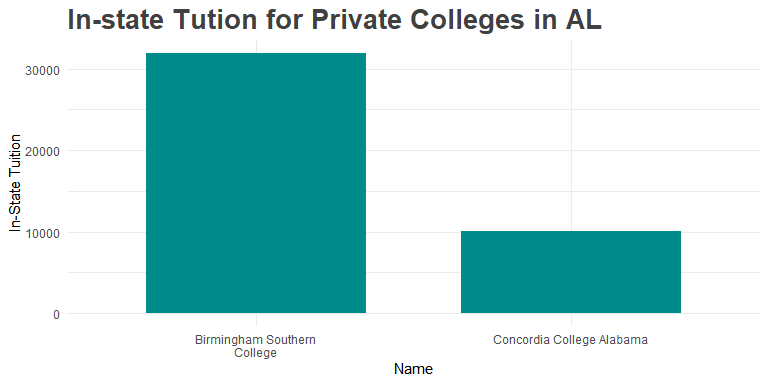

```r
privateCollegeBarGraph("AL")
```

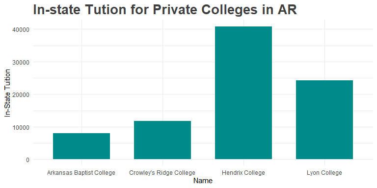

```r
privateCollegeBarGraph("AR")
```

[figure not shown]

```r
privateCollegeBarGraph("FL") # No Private Colleges
```

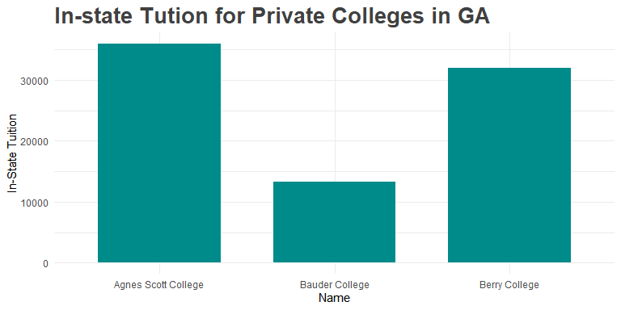

```r
privateCollegeBarGraph("GA")
```

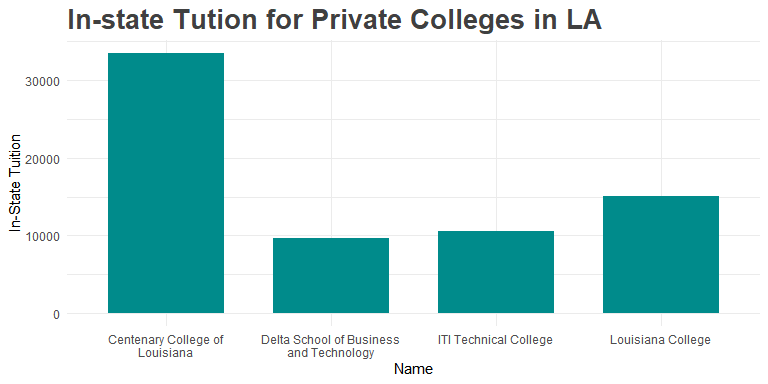

```r
privateCollegeBarGraph("LA")
```

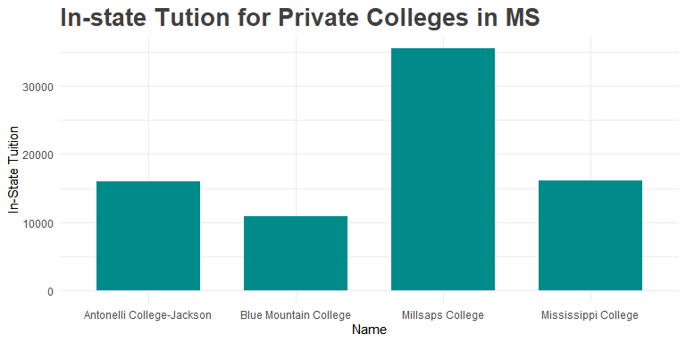

```r
privateCollegeBarGraph("MS")
```

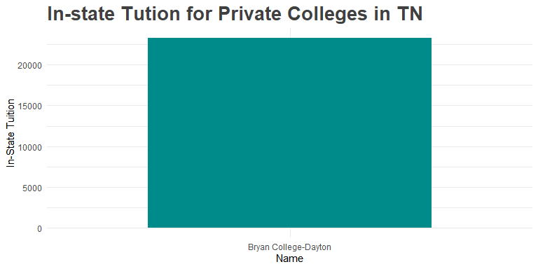

```r
privateCollegeBarGraph("TN")
```

### Selective states

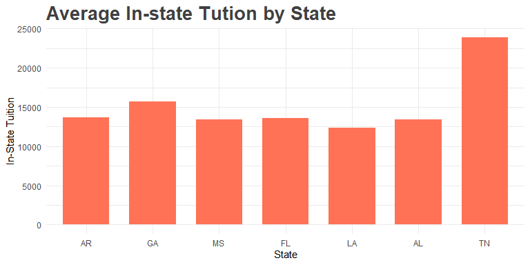

```r
selStates = c("AL", "AR", "FL", "GA", "LA", "MS", "TN")
inStateTuition_byState %>%
  filter(
    State %in% selStates
  ) %>%
  ggplot(aes(x = State, y = `In-State Tuition`)) +
  theme_minimal() +
  theme(plot.title = element_text(color = "grey25", size = 20, face = "bold")) +
  geom_bar(stat = "identity", fill = "coral1", width = 0.7) +
  ggtitle("Average In-state Tution by State")
```